# uGrid Project 1

Wencong Li

September 17, 2016

I only include sessions with an USA IP address in my dataset. Therefore, I only focus on the effect of `age`, `new_urser`, `source`, and `total_pages` on conversion rate.

```r
conversion_data <-read.csv("/Users/Priscilla/Desktop/SMITH/2016 Fall/uGrid_lwc/Proj_1/conversion_data.csv")
conversion_data %>%
  slice(1:10)
```

```
##    country age new_user source total_pages_visited converted
## 1       US  23        1    Seo                   5         0
## 2       US  28        1    Seo                   4         0
## 3       US  30        1    Seo                   6         0
## 4       US  31        0    Seo                   1         0
## 5       US  23        0    Ads                   4         0
## 6       US  25        0    Ads                   2         0
## 7       US  38        0    Seo                   1         0
## 8       US  43        1 Direct                   8         0
## 9       US  24        1    Seo                   4         0
## 10      US  39        0    Seo                   3         0
```

Missing value? The chunk below takes about 30 seconds. You might not wanna run it. `missmap` plots your dataset and highlight missing values:

```r
#library(Amelia)
#missmap(conversion_data, main = "Missing values vs. observed")
```

No missing value. Good.

Next step:

```r
str(conversion_data)
```

```
## 'data.frame':    178092 obs. of  6 variables:
##  $ country            : Factor w/ 1 level "US": 1 1 1 1 1 1 1 1 1 1 ...
##  $ age                : int  23 28 30 31 23 25 38 43 24 39 ...
##  $ new_user           : int  1 1 1 0 0 0 0 1 1 0 ...
##  $ source             : Factor w/ 3 levels "Ads","Direct",..: 3 3 3 3 1 1 3 2 3 3 ...
##  $ total_pages_visited: int  5 4 6 1 4 2 1 8 4 3 ...
##  $ converted          : int  0 0 0 0 0 0 0 0 0 0 ...
```

```r
dim(conversion_data)
```

```
## [1] 178092      6
```

```r
names(conversion_data)
```

```
## [1] "country"             "age"                 "new_user"
## [4] "source"              "total_pages_visited" "converted"
```

`new_urser` and `converted` were shown as numerical variables, but they are categorical variables, so we need to convert them.

```r
summary(conversion_data)
```

```
##  country          age           new_user        source
##  US:178092   Min.   :17.00   Min.   :0.000   Ads   :49901
##              1st Qu.:24.00   1st Qu.:0.000   Direct:40962
##              Median :30.00   Median :1.000   Seo   :87229
##              Mean   :30.57   Mean   :0.682
##              3rd Qu.:36.00   3rd Qu.:1.000
##              Max.   :79.00   Max.   :1.000
##  total_pages_visited   converted
##  Min.   : 1.00       Min.   :0.0000
##  1st Qu.: 2.00       1st Qu.:0.0000
##  Median : 4.00       Median :0.0000
##  Mean   : 4.93       Mean   :0.0378
##  3rd Qu.: 7.00       3rd Qu.:0.0000
##  Max.   :29.00       Max.   :1.0000
```

```r
conversion_data <- conversion_data %>%
  mutate(new_user = factor(new_user)) %>%
  mutate(converted = factor(converted))
summary(conversion_data)
```

```
##  country          age        new_user      source      total_pages_visited
##  US:178092   Min.   :17.00   0: 56636   Ads   :49901   Min.   : 1.00
##              1st Qu.:24.00   1:121456   Direct:40962   1st Qu.: 2.00
##              Median :30.00              Seo   :87229   Median : 4.00
##              Mean   :30.57                             Mean   : 4.93
##              3rd Qu.:36.00                             3rd Qu.: 7.00
##              Max.   :79.00                             Max.   :29.00
##  converted
##  0:171360
##  1:  6732
##
##
##
##
```

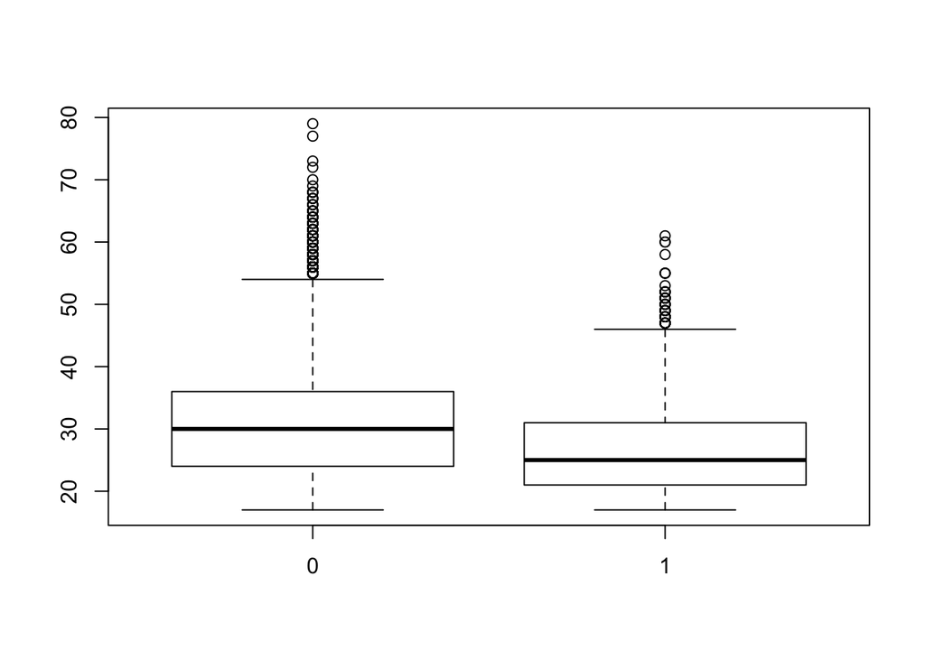

```r
boxplot(age ~ converted, data=conversion_data)
```

According to this boxplot, we might perdict that age is a crutial factor for conversion rate. It seems that the mean of age for people who left the site without buying anything is higher. Also, there is more varibility in age for prople who did not book any room.

I split the data into two chunks: training and testing set. The training set will be used to fit our model which we will be testing over the testing set.

```r
train <- conversion_data[1:130000,]
test <- conversion_data[130001:178092,]
```

```r
model_full <- glm(converted~ age + new_user + source+
                    total_pages_visited,
                  family=binomial(link='logit'),data=train)
summary(model_full)
```

```
##
## Call:
## glm(formula = converted ~ age + new_user + source + total_pages_visited,
##     family = binomial(link = "logit"), data = train)
##
## Deviance Residuals:
##     Min       1Q   Median       3Q      Max
## -3.1457  -0.0784  -0.0323  -0.0149   4.3983
##
## Coefficients:
##                      Estimate Std. Error z value Pr(>|z|)
## (Intercept)         -7.036624   0.131597 -53.471  < 2e-16 ***
## age                 -0.074445   0.003365 -22.124  < 2e-16 ***
## new_user1           -1.692113   0.050235 -33.684  < 2e-16 ***
## sourceDirect        -0.269857   0.068899  -3.917 8.98e-05 ***
## sourceSeo           -0.071452   0.056245  -1.270    0.204
## total_pages_visited  0.756390   0.008761  86.336  < 2e-16 ***
## ---
## Signif. codes:  0 '***' 0.001 '**' 0.01 '*' 0.05 '.' 0.1 ' ' 1
##
## (Dispersion parameter for binomial family taken to be 1)
##
##     Null deviance: 41954  on 129999  degrees of freedom
## Residual deviance: 12794  on 129994  degrees of freedom
## AIC: 12806
##
## Number of Fisher Scoring iterations: 9
```

First of all, we can see that `sourceSeo` is not statistically significant. As for the statistically significant variables, `age`, `new_urser`, and `total_pages_visited` have the lowest p-value suggesting strong associations of those three variables with conversion rate. Also, only `total_pages_visited` has a positive coefficient, suggestiong that all other variables being equal, people who visit more pages are more likely to book a room.

```r
anova(model_full, test="Chisq")
```

```
## Analysis of Deviance Table
##
## Model: binomial, link: logit
##
## Response: converted
##
## Terms added sequentially (first to last)
##
##
##                     Df Deviance Resid. Df Resid. Dev  Pr(>Chi)
## NULL                               129999      41954
## age                  1   1320.4    129998      40633 < 2.2e-16 ***
## new_user             1   3120.3    129997      37513 < 2.2e-16 ***
## source               2     27.8    129995      37485 9.188e-07 ***
## total_pages_visited  1  24691.5    129994      12794 < 2.2e-16 ***
## ---
## Signif. codes:  0 '***' 0.001 '**' 0.01 '*' 0.05 '.' 0.1 ' ' 1
```

The difference between the null deviance and the residual deviance shows how our model is doing against the null model (a model with only the intercept). The wider this gap, the better. Analyzing the table we can see the drop in deviance when adding each variable one at a time. Again, adding `age`, `new_user`, and `total_pages_visited` significantly reduces the residual deviance. `source` seem to improve the model less even though it has a low p-value.

Droping `source`: New Model

```r
model_2 <- glm(converted~ age + new_user +
                    total_pages_visited,
                  family=binomial(link='logit'),data=train)
summary(model_2)
```

```
##
## Call:
## glm(formula = converted ~ age + new_user + total_pages_visited,
##     family = binomial(link = "logit"), data = train)
##
## Deviance Residuals:
##     Min       1Q   Median       3Q      Max
## -3.1143  -0.0788  -0.0324  -0.0150   4.4184
##
## Coefficients:
##                      Estimate Std. Error z value Pr(>|z|)
## (Intercept)         -7.130113   0.126177  -56.51   <2e-16 ***
## age                 -0.074270   0.003361  -22.10   <2e-16 ***
## new_user1           -1.691890   0.050206  -33.70   <2e-16 ***
## total_pages_visited  0.755866   0.008748   86.40   <2e-16 ***
## ---
## Signif. codes:  0 '***' 0.001 '**' 0.01 '*' 0.05 '.' 0.1 ' ' 1
##
## (Dispersion parameter for binomial family taken to be 1)
##
##     Null deviance: 41954  on 129999  degrees of freedom
## Residual deviance: 12810  on 129996  degrees of freedom
## AIC: 12818
##
## Number of Fisher Scoring iterations: 9
```

I did not have enought time to chhose a reasonable desicion boundary, so let’s just use 0.5 as the boundary. If P(y=1|X) > 0.5 then y = 1 otherwise y=0.

```r
fitted.results <- predict(model_2, newdata =  subset(test, type = 'response'))
fitted.results <- ifelse(fitted.results > 0.5,1,0)
misClasificError <- mean(fitted.results != test$converted)
print(paste('Accuracy',1-misClasificError))
```

```
## [1] "Accuracy 0.983074107959744"
```

The 0.983 accuracy on the test set is quite a good result. However, keep in mind that this result is somewhat dependent on the manual split of the data that I made earlier, therefore if you wish for a more precise score, you would be better off running some kind of cross validation such as k-fold cross validation.

As a last step, we are going to plot the ROC curve and calculate the area under the curve, which are typical performance measurements for a binary classifier.

```r
library(ROCR)
```

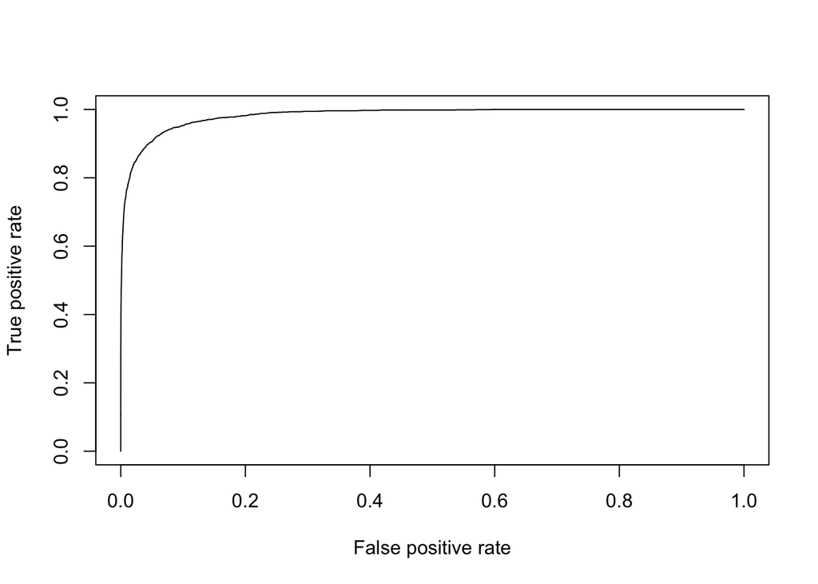

```r
p <- predict(model_2, newdata=subset(test), type="response")
pr <- prediction(p, test$converted)
prf <- performance(pr, measure = "tpr", x.measure = "fpr")
plot(prf)
```

```r
auc <- performance(pr, measure = "auc")
auc <- auc@y.values[[1]]
auc
```

```
## [1] 0.9831566
```

0.983